# Investigating the spread of COVID-19

10 May, 2021

## Introduction

### Covid-19 and goals for the project

**Our goal** : Investigate how/if selected global socio-economic factors are correlated with the spread of Covid-19

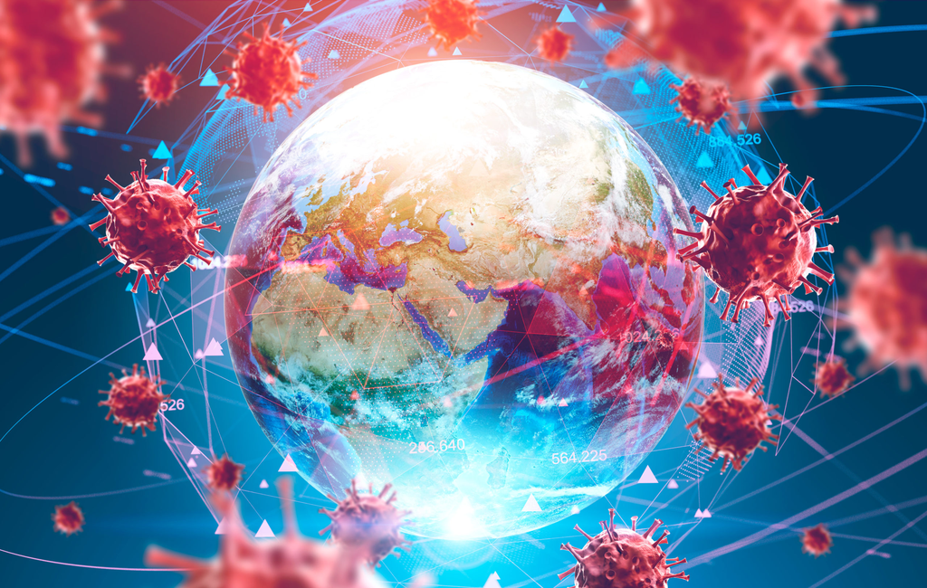

photo from::https://sdbi.in/artificial-intelligence-and-big-data-to-control-covid-19"

## Materials and methods

### Datasets and workflow

- Covid-19 data from the github repository of John Hopkins University
- Demographic and social factors on a country basis from gapminder and worldbank
- Latitude and longitude data for countries is from the “maps” package dataset

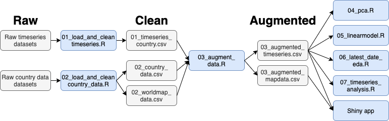

## Materials and methods

### Cleaning & Augmenting

**Cleaning: Issues with dataset:**

- Timeseries data in very wide format
- Country names were not consistent over data sources
- Multiple files had to be combined
- Recovered are reported inconsistently

**Augmentation:**

- Calculate cases, deaths, and recoveries per 100K citizens
- Additional augmentations with rolling means and new cases per day
- For shiny app: Join latitude and longitude data to the country level Covid data.

## Materials and methods

### Data exploration and models

- Initial exploratory data analysis (eda)
- modelling:
  - PCA analysis: any trends, clusters, outliers in cases via countries and dependent variables?
  - 2 linear regression models (\(y=\beta_0 + \beta_1 x_1+ \beta_2 x_2 + \epsilon\)):
    - \(x_1\) = Pop % above 65, \(x_2\) = Urban pop %. Grouped by income level
    - \(x_1\) = GDP, \(x_2\) = Pop density. Grouped by region
- Exploring Covid “waves” and case fatality

## Results - Exploratory Data Analysis

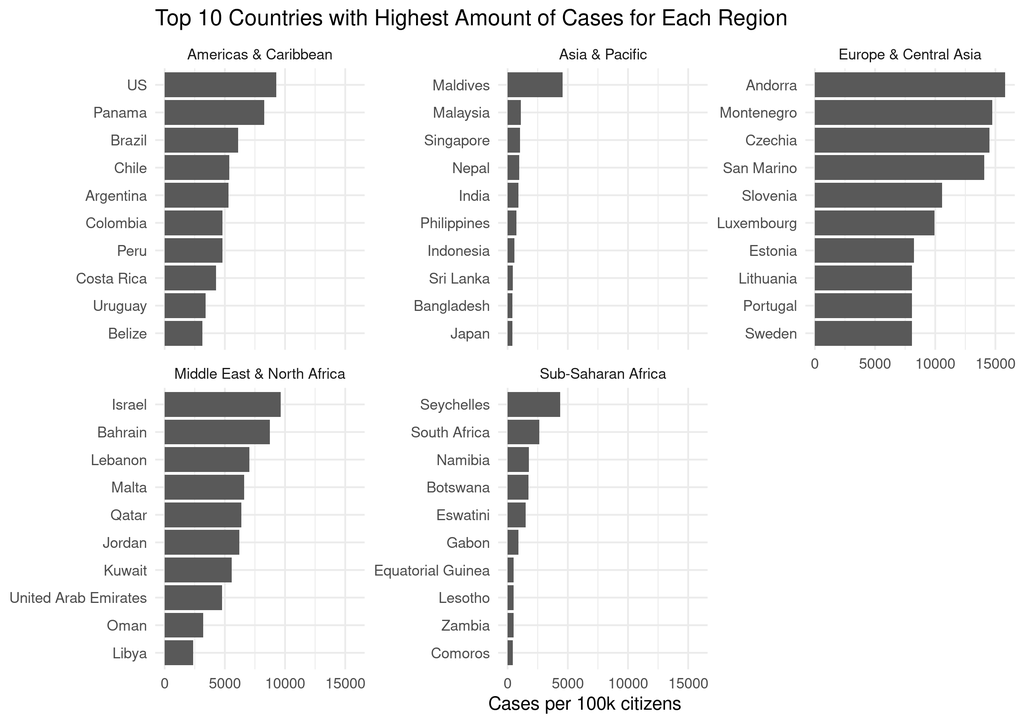

## Results - Exploratory Data Analysis

### Visualise correlation between income groups

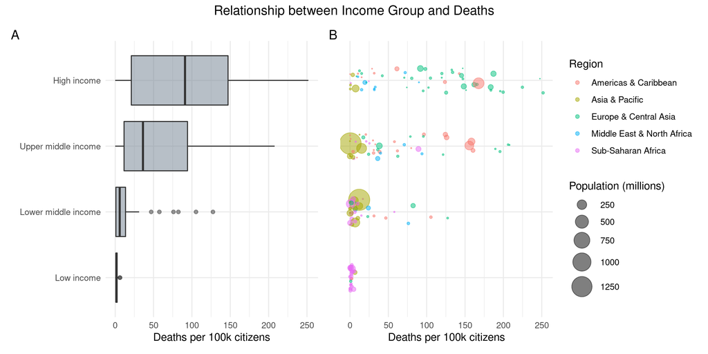

## Results - PCA

- PC 1 explains differences in cases fairly well
- Some countries are outliers in this projection

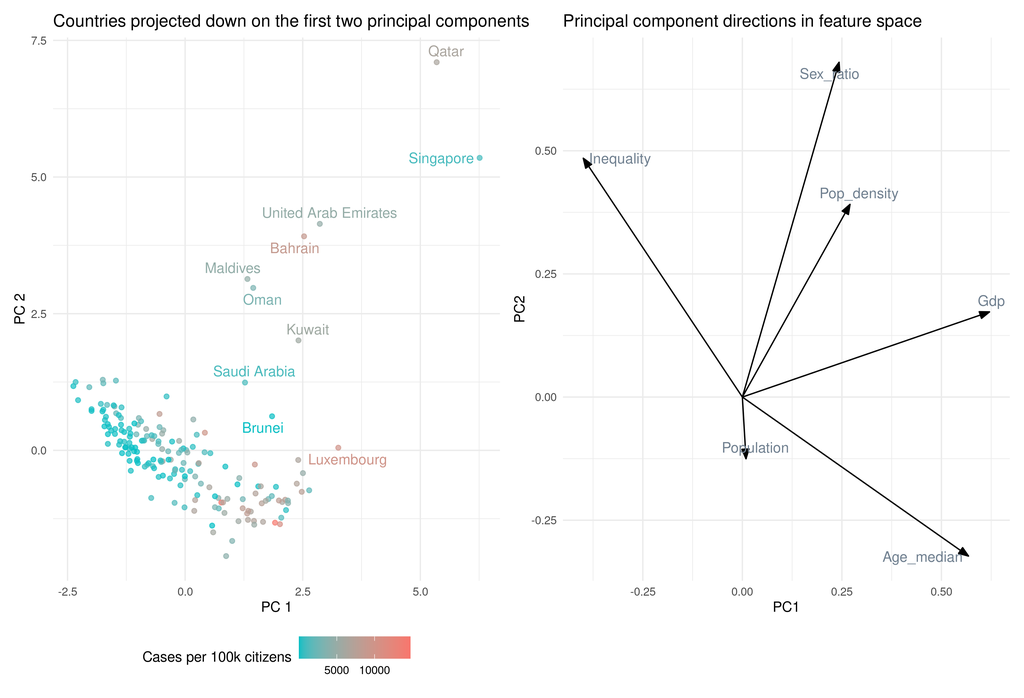

## Results - Linear regression model

- Deaths vs. (A) Population % above 65 years and (B) Population % living in urban areas. Grouped by income level.

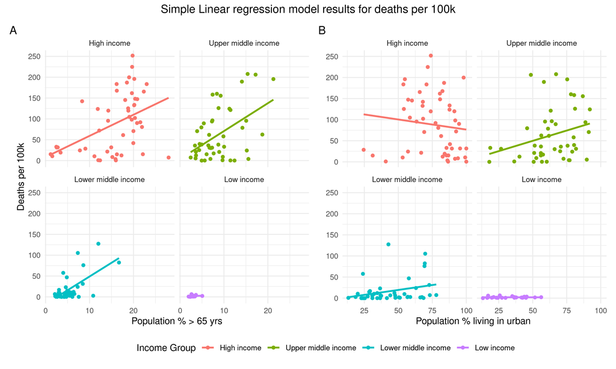

## Results - Linear regression model

**Significant slopes**

- population % above 65 years with high, upper middle and lower middle income
- population % in urban areas with upper middle income.

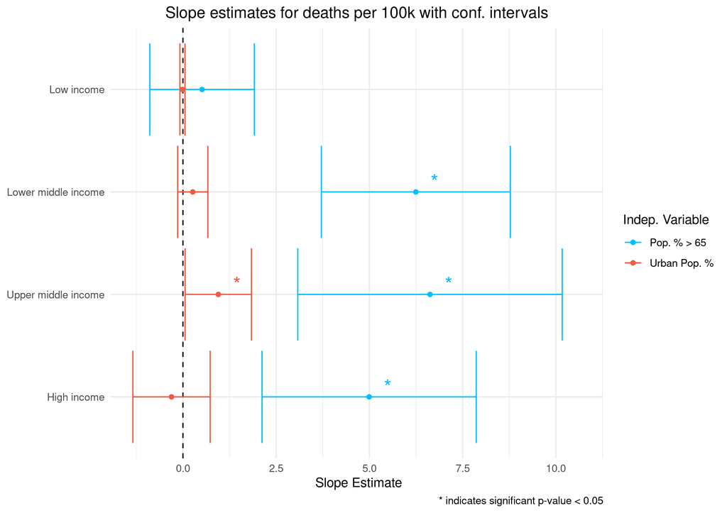

## Results - Identifying covid waves

- What is a good criteria for a wave?
  - We found that a weekly increase 10% in deaths is a good identifier

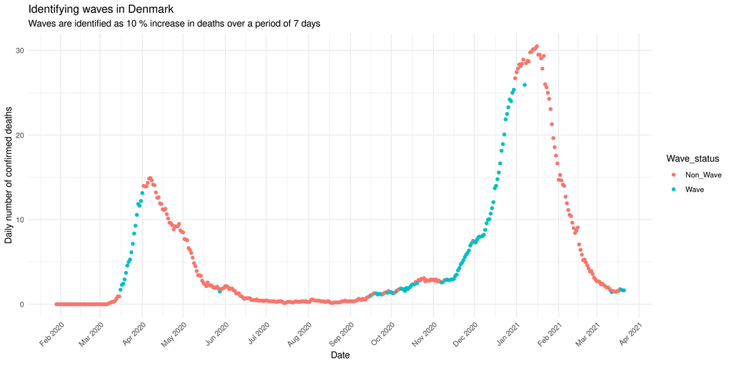

## Results - Identifying covid waves

- Do Covid-19 waves appear to be synchronized in different countries?

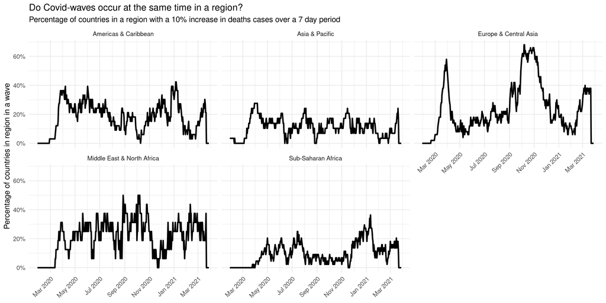

## Covid-19 overview Shiny App

https://christianjohansen.shinyapps.io/covid-19_app/

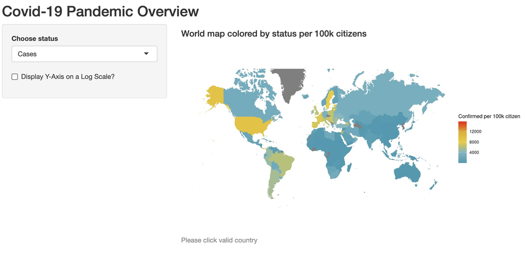

## Discussion

- In general from eda and linear regression, data suggests that more developed countries are hit “harder” by Covid-19.
  - This could be due to less developed countries having a younger avg. age (higher general mortality rates), thus younger populations are less severely influenced by infection. Slide 9 figure we see that low income countries have smallest range in the percent of pop. above 65 yrs.
  - However, here we have not considered for example:
    - Data quality/under reporting between countries. i.e. higher income countries will have better ability and excess to testing, thus more cases and deaths will be reported.
- We see that Covid “waves” are not synchronous between global regions.
  - Some regions had very visually distinct peaks of waves over time (Europe & Central Asia), while other were less distinct (Asia & Pacific)
  - Regionally Europe & Central Asia had the highest percentage of countries in waves at a certen time. At the highest peak almost 70% of the countries in the region were in a wave.

## Conclusion:

We want to point out that by looking at at correlations we are not inferring causation. In addition our linear model is not dealing with collinearity of features.